# Customer Service Requests Analysis.

Course-end Project 1

### Description

You've been asked to perform data analysis of service request (311) calls from New York City. You've also been asked to utilize data wrangling techniques to understand the pattern in the data and visualize the major types of complaints.

### Note:

Download 311-service-requests-nyc.zip file using the link given in the Customer Service Requests Analysis project problem statement and extract the 311_Service_Requests_from_2010_to_Present.csv file

1. Perform the following steps:
   1. Understand the dataset:
   2. Identify the shape of the dataset
   3. Identify variables with null values
2. Perform basic data exploratory analysis:
   1. Utilize missing value treatment
   2. Analyze the date column and remove the entries if it has an incorrect timeline
      1. Draw a frequency plot for city-wise complaints
      2. Draw scatter and hexbin plots for complaint concentration across Brooklyn
3. Find major types of complaints:
   1. Plot a bar graph of count vs. complaint types
   2. Find the top 10 types of complaints
   3. Display the types of complaints in each city in a separate dataset
4. Visualize the major types of complaints in each city
5. Check if the average response time across various types of complaints
6. Identify significant variables by performing a statistical analysis using p-values and chi-square values (Optional)

link to problem statement

```python
# import libararies

import pandas as pd
import matplotlib.pyplot as plt

%matplotlib inline
```

# 1. Understanding the dataset

## 1.1 Importing the dataset

```python
# import the dataset
df = pd.read_csv('../Datasets/311_Service_Requests_from_2010_to_Present.csv', low_memory=False)
```

```python
df.head()
```

|  | Unique Key | Created Date | Closed Date | Agency | Agency Name | Complaint Type | Descriptor | Location Type | Incident Zip | Incident Address | ... | Bridge Highway Name | Bridge Highway Direction | Road Ramp | Bridge Highway Segment | Garage Lot Name | Ferry Direction | Ferry Terminal Name | Latitude | Longitude | Location |
| --- | --- | --- | --- | --- | --- | --- | --- | --- | --- | --- | --- | --- | --- | --- | --- | --- | --- | --- | --- | --- | --- |
| 0 | 32310363 | 12/31/2015 11:59:45 PM | 01/01/2016 12:55:15 AM | NYPD | New York City Police Department | Noise - Street/Sidewalk | Loud Music/Party | Street/Sidewalk | 10034.0 | 71 VERMILYEA AVENUE | ... | NaN | NaN | NaN | NaN | NaN | NaN | NaN | 40.865682 | -73.923501 | (40.86568153633767, -73.92350095571744) |
| 1 | 32309934 | 12/31/2015 11:59:44 PM | 01/01/2016 01:26:57 AM | NYPD | New York City Police Department | Blocked Driveway | No Access | Street/Sidewalk | 11105.0 | 27-07 23 AVENUE | ... | NaN | NaN | NaN | NaN | NaN | NaN | NaN | 40.775945 | -73.915094 | (40.775945312321085, -73.91509393898605) |
| 2 | 32309159 | 12/31/2015 11:59:29 PM | 01/01/2016 04:51:03 AM | NYPD | New York City Police Department | Blocked Driveway | No Access | Street/Sidewalk | 10458.0 | 2897 VALENTINE AVENUE | ... | NaN | NaN | NaN | NaN | NaN | NaN | NaN | 40.870325 | -73.888525 | (40.870324522111424, -73.88852464418646) |
| 3 | 32305098 | 12/31/2015 11:57:46 PM | 01/01/2016 07:43:13 AM | NYPD | New York City Police Department | Illegal Parking | Commercial Overnight Parking | Street/Sidewalk | 10461.0 | 2940 BAISLEY AVENUE | ... | NaN | NaN | NaN | NaN | NaN | NaN | NaN | 40.835994 | -73.828379 | (40.83599404683083, -73.82837939584206) |
| 4 | 32306529 | 12/31/2015 11:56:58 PM | 01/01/2016 03:24:42 AM | NYPD | New York City Police Department | Illegal Parking | Blocked Sidewalk | Street/Sidewalk | 11373.0 | 87-14 57 ROAD | ... | NaN | NaN | NaN | NaN | NaN | NaN | NaN | 40.733060 | -73.874170 | (40.733059618956815, -73.87416975810375) |

5 rows × 53 columns

```python
df.tail()
```

|  | Unique Key | Created Date | Closed Date | Agency | Agency Name | Complaint Type | Descriptor | Location Type | Incident Zip | Incident Address | ... | Bridge Highway Name | Bridge Highway Direction | Road Ramp | Bridge Highway Segment | Garage Lot Name | Ferry Direction | Ferry Terminal Name | Latitude | Longitude | Location |
| --- | --- | --- | --- | --- | --- | --- | --- | --- | --- | --- | --- | --- | --- | --- | --- | --- | --- | --- | --- | --- | --- |
| 364553 | 29609918 | 01/01/2015 12:04:44 AM | 01/01/2015 10:22:31 AM | NYPD | New York City Police Department | Illegal Parking | Blocked Hydrant | Street/Sidewalk | 11421.0 | 84-25 85 ROAD | ... | NaN | NaN | NaN | NaN | NaN | NaN | NaN | 40.695145 | -73.860949 | (40.69514470265117, -73.86094888534394) |
| 364554 | 29608392 | 01/01/2015 12:04:28 AM | 01/01/2015 02:25:02 AM | NYPD | New York City Police Department | Noise - Vehicle | Car/Truck Horn | Street/Sidewalk | 10468.0 | 2555 SEDGWICK AVENUE | ... | NaN | NaN | NaN | NaN | NaN | NaN | NaN | 40.867830 | -73.907178 | (40.86782963689454, -73.90717786644662) |
| 364555 | 29607589 | 01/01/2015 12:01:30 AM | 01/01/2015 12:20:33 AM | NYPD | New York City Police Department | Noise - Street/Sidewalk | Loud Music/Party | Street/Sidewalk | 10031.0 | 508 WEST 139 STREET | ... | NaN | NaN | NaN | NaN | NaN | NaN | NaN | 40.821647 | -73.950873 | (40.821646626438095, -73.95087342885292) |
| 364556 | 29610889 | 01/01/2015 12:01:29 AM | 01/01/2015 02:42:22 AM | NYPD | New York City Police Department | Blocked Driveway | No Access | Street/Sidewalk | 10466.0 | 931 EAST 226 STREET | ... | NaN | NaN | NaN | NaN | NaN | NaN | NaN | 40.886361 | -73.853290 | (40.88636077906953, -73.85329048666742) |
| 364557 | 29611816 | 01/01/2015 12:00:50 AM | 01/01/2015 02:47:50 AM | NYPD | New York City Police Department | Blocked Driveway | No Access | Street/Sidewalk | 11420.0 | 123-19 135 STREET | ... | NaN | NaN | NaN | NaN | NaN | NaN | NaN | 40.674212 | -73.803585 | (40.674211762243935, -73.80358548685278) |

5 rows × 53 columns

## 1.2 Visualize the dataset

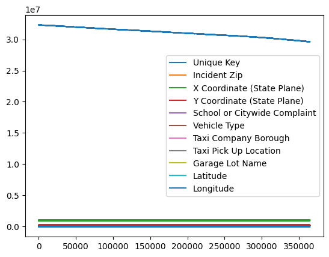

```python
# Visualize the dataset
df.plot()
```

## 1.3 print columns of dataframe

```python
print(df.columns)
```

```
Index(['Unique Key', 'Created Date', 'Closed Date', 'Agency', 'Agency Name',
       'Complaint Type', 'Descriptor', 'Location Type', 'Incident Zip',
       'Incident Address', 'Street Name', 'Cross Street 1', 'Cross Street 2',
       'Intersection Street 1', 'Intersection Street 2', 'Address Type',
       'City', 'Landmark', 'Facility Type', 'Status', 'Due Date',
       'Resolution Description', 'Resolution Action Updated Date',
       'Community Board', 'Borough', 'X Coordinate (State Plane)',
       'Y Coordinate (State Plane)', 'Park Facility Name', 'Park Borough',
       'School Name', 'School Number', 'School Region', 'School Code',
       'School Phone Number', 'School Address', 'School City', 'School State',
       'School Zip', 'School Not Found', 'School or Citywide Complaint',
       'Vehicle Type', 'Taxi Company Borough', 'Taxi Pick Up Location',
       'Bridge Highway Name', 'Bridge Highway Direction', 'Road Ramp',
       'Bridge Highway Segment', 'Garage Lot Name', 'Ferry Direction',
       'Ferry Terminal Name', 'Latitude', 'Longitude', 'Location'],
      dtype='object')
```

## 1.4 Identify the shape of the dataset

```python
df.shape
```

```
(364558, 53)
```

## 1.5 Identify the variables with null values

```python
df.isna()
```

|  | Unique Key | Created Date | Closed Date | Agency | Agency Name | Complaint Type | Descriptor | Location Type | Incident Zip | Incident Address | ... | Bridge Highway Name | Bridge Highway Direction | Road Ramp | Bridge Highway Segment | Garage Lot Name | Ferry Direction | Ferry Terminal Name | Latitude | Longitude | Location |
| --- | --- | --- | --- | --- | --- | --- | --- | --- | --- | --- | --- | --- | --- | --- | --- | --- | --- | --- | --- | --- | --- |
| 0 | False | False | False | False | False | False | False | False | False | False | ... | True | True | True | True | True | True | True | False | False | False |
| 1 | False | False | False | False | False | False | False | False | False | False | ... | True | True | True | True | True | True | True | False | False | False |
| 2 | False | False | False | False | False | False | False | False | False | False | ... | True | True | True | True | True | True | True | False | False | False |
| 3 | False | False | False | False | False | False | False | False | False | False | ... | True | True | True | True | True | True | True | False | False | False |
| 4 | False | False | False | False | False | False | False | False | False | False | ... | True | True | True | True | True | True | True | False | False | False |
| ... | ... | ... | ... | ... | ... | ... | ... | ... | ... | ... | ... | ... | ... | ... | ... | ... | ... | ... | ... | ... | ... |
| 364553 | False | False | False | False | False | False | False | False | False | False | ... | True | True | True | True | True | True | True | False | False | False |
| 364554 | False | False | False | False | False | False | False | False | False | False | ... | True | True | True | True | True | True | True | False | False | False |
| 364555 | False | False | False | False | False | False | False | False | False | False | ... | True | True | True | True | True | True | True | False | False | False |
| 364556 | False | False | False | False | False | False | False | False | False | False | ... | True | True | True | True | True | True | True | False | False | False |
| 364557 | False | False | False | False | False | False | False | False | False | False | ... | True | True | True | True | True | True | True | False | False | False |

364558 rows × 53 columns

# 2. Perform basic data exploratory analysis

## 2.1 Draw a frequency plot to show the number of null values in each column of the DataFrame

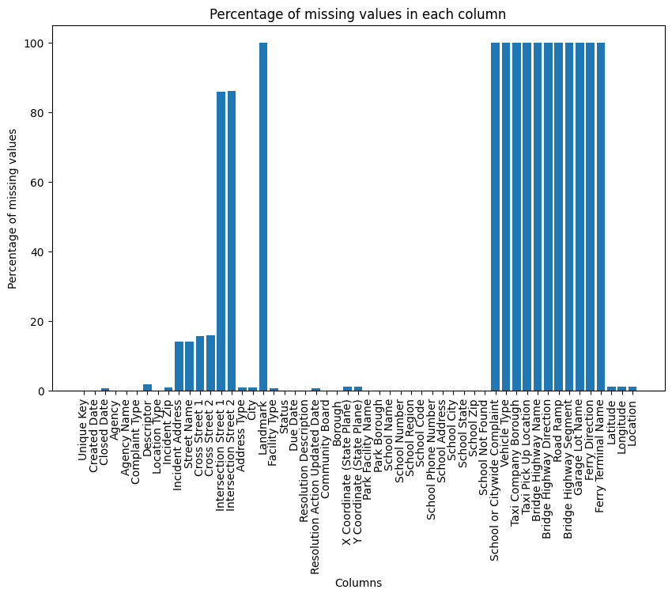

```python
percentage_of_missing_values = (df.isna().sum(axis=0)/df.shape[0])*100
plt.figure(figsize=(10, 6))
plt.bar(percentage_of_missing_values.index, percentage_of_missing_values)
plt.xlabel('Columns')
plt.ylabel('Percentage of missing values')
plt.title('Percentage of missing values in each column')
plt.xticks(rotation=90)
plt.show()
```

## 2.2 Missing value treatment

### 2.2.1 Remove the records whose closed date value are null

```python
df1 = df.dropna(subset=['Closed Date'], axis=0)
```

## 2.3 Analyze the data column, and remove entries that have an incorrent timeline

```python
# Convert Timeline columns to datetime, coerce errors to NaT (Not a Time)
df1['Closed Date'] = pd.to_datetime(df1['Closed Date'], errors='coerce')
df1['Created Date'] = pd.to_datetime(df1['Created Date'], errors='coerce')

# Set your criteria for valid date range (adjust as needed)
min_date = pd.to_datetime('1900-01-01')  # replace with your minimum valid date
max_date = pd.to_datetime('2023-12-31')  # replace with your maximum valid date

# Filter rows based on the date range
df1 = df1[(df1['Closed Date'] >= min_date) &
        (df1['Closed Date'] <= max_date)]

df1 = df1[(df1['Created Date'] >= min_date) &
        (df1['Created Date'] <= max_date)]
```

## 2.3.1 Calculate the time elapsed in closed and creation date

```python
# Calculate the time elapsed in closed and creation date
time_elapsed = df1['Closed Date'] - df1['Created Date']
```

### 2.3.2 Convert the calculated time elapsed into seconds

```python
# Convert the calculated time elapsed into seconds
time_elapsed_in_seconds = time_elapsed.dt.total_seconds()
```

### 2.3.3 View the descriptive statiscts for the new created column

```python
# View the descriptive statiscts for the new created column
time_elapsed_in_seconds.describe()
```

```
count    3.621770e+05
mean     1.511330e+04
std      2.110255e+04
min      6.100000e+01
25%      4.533000e+03
50%      9.616000e+03
75%      1.887800e+04
max      2.134342e+06
dtype: float64
```

### 2.3.4 Check the number of null values in the Complaint_Type and City columns

```python
# Check the number of null values in the Complaint_Type and City columns
df1[['Complaint Type', 'City']].isna().sum(axis=0)
```

```
Complaint Type      0
City              674
dtype: int64
```

### 2.3.5 Impute the NA value with 'Unknown City'

```python
# Impute the NA value with 'Unknown City'
df1.loc[df1['City'].isna(), 'City'] = 'Unknown City'
```

### 2.3.6 Draw a frequency plot for the complaints in each city

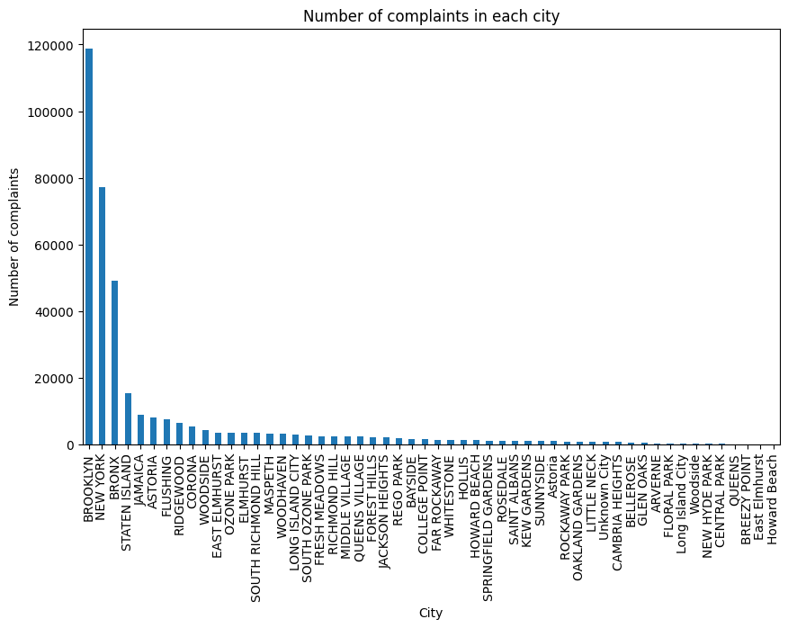

```python
# Draw a frequency plot for the complaints in each city
plt.figure(figsize=(10, 6))
df1['City'].value_counts().plot(kind='bar')
plt.xlabel('City')
plt.ylabel('Number of complaints')
plt.title('Number of complaints in each city')
plt.xticks(rotation=90)
plt.show()
```

### 2.3.7 Create a scatter and hexbin plot of the concentration of complaints across Brooklyn

[figure not shown]

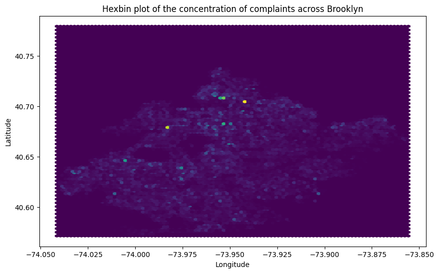

```python
# Create a scatter and hexbin plot of the concentration of complaints across Brooklyn

broolyn_df = df1[df1['City'] == 'BROOKLYN']
plt.figure(figsize=(10, 6))
plt.scatter(broolyn_df['Latitude'], broolyn_df['Latitude'])
plt.xlabel('Longitude')
plt.ylabel('Latitude')
plt.title('Scatter plot of the concentration of complaints across Brooklyn')
plt.show()

plt.figure(figsize=(10, 6))
plt.hexbin(broolyn_df['Longitude'], broolyn_df['Latitude'], gridsize=100)
plt.xlabel('Longitude')
plt.ylabel('Latitude')
plt.title('Hexbin plot of the concentration of complaints across Brooklyn')
plt.show()
```

# 3. Find major types of complaints

## 3.1 Plot a bar graph to show the types of complaints

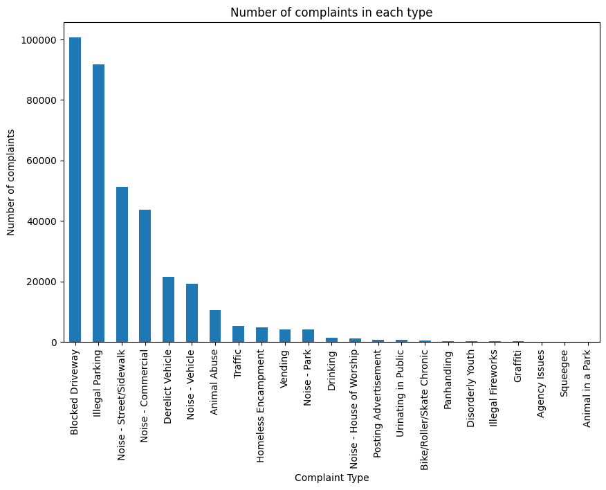

```python
# Plot a bar graph to show the types of complaints

plt.figure(figsize=(10, 6))
df1['Complaint Type'].value_counts().plot(kind='bar')
plt.xlabel('Complaint Type')
plt.ylabel('Number of complaints')
plt.title('Number of complaints in each type')
plt.xticks(rotation=90)
plt.show()
```

## 3.2 Check the frequency of Complaint type in Newyork city

```python
# Check the frequency of Complaint type in Newyork city
newyork_df = df1[df1['City'] == 'NEW YORK']
percentage_of_complaint_type_newyork = (newyork_df['Complaint Type'].value_counts()/df.shape[0])*100
percentage_of_complaint_type_newyork
```

```
Complaint Type
Noise - Street/Sidewalk      6.101910
Noise - Commercial           5.125659
Illegal Parking              3.990860
Noise - Vehicle              1.726474
Homeless Encampment          0.839373
Blocked Driveway             0.741994
Vending                      0.723616
Animal Abuse                 0.532426
Traffic                      0.485245
Noise - Park                 0.340961
Derelict Vehicle             0.190642
Drinking                     0.088052
Urinating in Public          0.072416
Bike/Roller/Skate Chronic    0.069673
Noise - House of Worship     0.060896
Panhandling                  0.056507
Disorderly Youth             0.022219
Posting Advertisement        0.013441
Illegal Fireworks            0.010424
Graffiti                     0.006858
Squeegee                     0.001097
Name: count, dtype: float64
```

## 3.3 Find the top 10 complaint types in Newyork city

```python
# Find the top 10 complaint types in Newyork city
top_10_complaint_types_newyork = percentage_of_complaint_type_newyork.head(10)
top_10_complaint_types_newyork
```

```
Complaint Type
Noise - Street/Sidewalk    6.101910
Noise - Commercial         5.125659
Illegal Parking            3.990860
Noise - Vehicle            1.726474
Homeless Encampment        0.839373
Blocked Driveway           0.741994
Vending                    0.723616
Animal Abuse               0.532426
Traffic                    0.485245
Noise - Park               0.340961
Name: count, dtype: float64
```

## 3.4 Display the various types of complaints in each city

```python
# Display the various types of complaints in each city
df1.groupby('City')['Complaint Type'].value_counts()
```

```
City      Complaint Type
ARVERNE   Illegal Parking             62
          Blocked Driveway            50
          Animal Abuse                46
          Derelict Vehicle            32
          Noise - Street/Sidewalk     29
                                    ...
Woodside  Illegal Parking            124
          Blocked Driveway            27
          Derelict Vehicle             8
          Noise - Street/Sidewalk      5
          Noise - Commercial           2
Name: count, Length: 792, dtype: int64
```

## 3.5 Create a DataFrame, df_new, which contains cities as columns and complaint types in rows

```python
# Create a DataFrame, df_new, which contains cities as columns and complaint types in rows
df_new = df1.groupby('Complaint Type')['City'].value_counts().unstack()
df_new.head()
```

| City Complaint Type | ARVERNE | ASTORIA | Astoria | BAYSIDE | BELLEROSE | BREEZY POINT | BRONX | BROOKLYN | CAMBRIA HEIGHTS | CENTRAL PARK | ... | SOUTH OZONE PARK | SOUTH RICHMOND HILL | SPRINGFIELD GARDENS | STATEN ISLAND | SUNNYSIDE | Unknown City | WHITESTONE | WOODHAVEN | WOODSIDE | Woodside |
| --- | --- | --- | --- | --- | --- | --- | --- | --- | --- | --- | --- | --- | --- | --- | --- | --- | --- | --- | --- | --- | --- |
| Agency Issues | NaN | NaN | NaN | NaN | NaN | NaN | NaN | NaN | NaN | NaN | ... | NaN | NaN | NaN | NaN | NaN | 8.0 | NaN | NaN | NaN | NaN |
| Animal Abuse | 46.0 | 170.0 | NaN | 53.0 | 15.0 | 2.0 | 1971.0 | 3191.0 | 15.0 | NaN | ... | 74.0 | 40.0 | 42.0 | 786.0 | 40.0 | 1.0 | 43.0 | 57.0 | 111.0 | NaN |
| Animal in a Park | NaN | NaN | NaN | NaN | NaN | NaN | NaN | NaN | NaN | NaN | ... | NaN | NaN | NaN | NaN | NaN | NaN | NaN | NaN | NaN | NaN |
| Bike/Roller/Skate Chronic | NaN | 16.0 | NaN | NaN | 1.0 | NaN | 22.0 | 124.0 | NaN | NaN | ... | 1.0 | 1.0 | NaN | 10.0 | 2.0 | 2.0 | 4.0 | 2.0 | 5.0 | NaN |
| Blocked Driveway | 50.0 | 3436.0 | 159.0 | 514.0 | 138.0 | 3.0 | 17062.0 | 36445.0 | 177.0 | NaN | ... | 1202.0 | 1946.0 | 330.0 | 2845.0 | 278.0 | 86.0 | 279.0 | 1363.0 | 2038.0 | 27.0 |

5 rows × 54 columns

# 4. Visualize the major types of complaints in each city

```
                    City           Complaint Type  Count
7                ARVERNE          Illegal Parking     62
19               ASTORIA         Blocked Driveway   3436
40               Astoria       Noise - Commercial    311
49               BAYSIDE          Illegal Parking    638
59             BELLEROSE         Blocked Driveway    138
79          BREEZY POINT          Illegal Parking     16
85                 BRONX         Blocked Driveway  17063
105             BROOKLYN         Blocked Driveway  36447
124      CAMBRIA HEIGHTS         Blocked Driveway    177
135         CENTRAL PARK  Noise - Street/Sidewalk    105
137        COLLEGE POINT         Blocked Driveway    597
152               CORONA         Blocked Driveway   3597
171        EAST ELMHURST         Blocked Driveway   1925
189             ELMHURST         Blocked Driveway   1992
```

[output cut: 39 more lines]

[figure not shown]

```python
# Visualize the major types of complaints in each city
complaint_counts = df.groupby(['City', 'Complaint Type']).size()

complaint_count = complaint_counts.reset_index(name='Count')

major_complaints = complaint_count.loc[complaint_count.groupby('City')['Count'].idxmax()]

print(major_complaints)

major_complaints.plot(kind='bar', figsize=(20, 6))
plt.xlabel('Complaint Type')
plt.ylabel('Number of complaints')
plt.title('Number of complaints in each type')
plt.xticks(rotation=90)
plt.show()
```

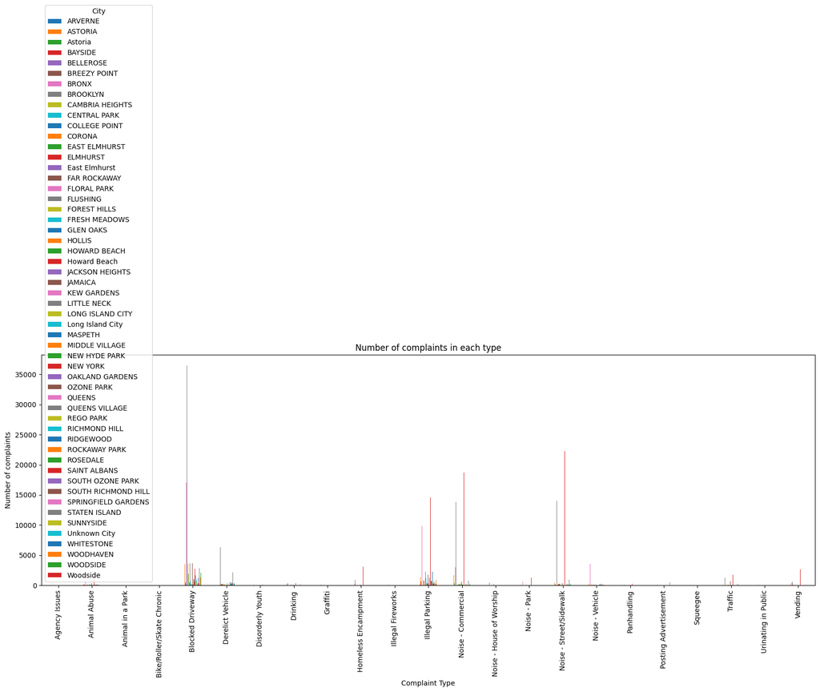

```python
df_new.plot(kind='bar', figsize=(20, 6))
plt.xlabel('Complaint Type')
plt.ylabel('Number of complaints')
plt.title('Number of complaints in each type')
plt.xticks(rotation=90)
plt.show()
```

## 4.2 Sort the complaint types based on the average Request_Closing_Time grouping them for different locations

```python
df1['Response Time'] = time_elapsed_in_seconds / (60 * 60)  # Convert to hours

# Create a DataFrame with the average closing time for each complaint type and location
avg_closing_time = df1.groupby(['Complaint Type', 'Location'])['Response Time'].mean().reset_index()

# Sort the DataFrame by average closing time
sorted_df = avg_closing_time.sort_values(by='Response Time')

# Display the sorted DataFrame
sorted_df
```

|  | Complaint Type | Location | Response Time |
| --- | --- | --- | --- |
| 127814 | Noise - Commercial | (40.678429539269835, -73.98361397723242) | 0.043611 |
| 131340 | Noise - Commercial | (40.72895633655987, -74.00074325193769) | 0.043611 |
| 167976 | Noise - Vehicle | (40.76848580086362, -73.91235250532725) | 0.045278 |
| 100127 | Illegal Parking | (40.69371028050496, -73.95499211670034) | 0.046389 |
| 151485 | Noise - Street/Sidewalk | (40.764596652420956, -73.97372678473167) | 0.046944 |
| ... | ... | ... | ... |
| 63259 | Derelict Vehicle | (40.64465625507198, -73.95663234950166) | 200.606250 |
| 63261 | Derelict Vehicle | (40.64466438582295, -73.95635848114169) | 223.351667 |
| 63277 | Derelict Vehicle | (40.64496727639598, -73.95897801142875) | 223.370000 |
| 144407 | Noise - Street/Sidewalk | (40.68594971751218, -73.95942153955151) | 297.859306 |
| 82081 | Illegal Parking | (40.59814521498835, -73.98935198928409) | 577.351667 |

178163 rows × 3 columns